# PA1_template.Rmd

rScientist

September 18, 2015

This is an R Markdown document intended to fill the requirements of the Reproducible Research Peer Assesment 1.

## Loading and preprocessing the data

1. Load the data (i.e. read.csv())

```r
ads <- read.csv("activity.csv")
```

2. Process/transform the data (if necessary) into a format suitable for your analysis

```r
ads$date <- as.Date(ads$date)
```

## What is mean total number of steps taken per day?

1. Calculate the total steps taken per day

```r
daily_steps_sum <- tapply(ads$steps, format(ads$date, '%d-%m-%Y'), sum)
```

2. Make a histogram of the total number of steps taken each day

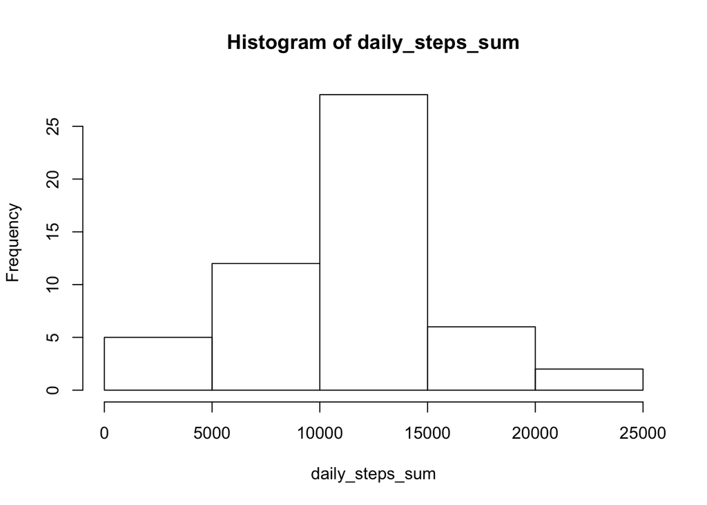

```r
hist(daily_steps_sum)
```

```r
daily_steps_mean <- mean(daily_steps_sum, na.rm = TRUE)
daily_steps_median <- median(daily_steps_sum, na.rm = TRUE)
```

## What is the average daily activity pattern?

1. Make a time series plot (i.e. type = “l”) of the 5-minute interval (x-axis) and the average number of steps taken, averaged across all days (y-axis)

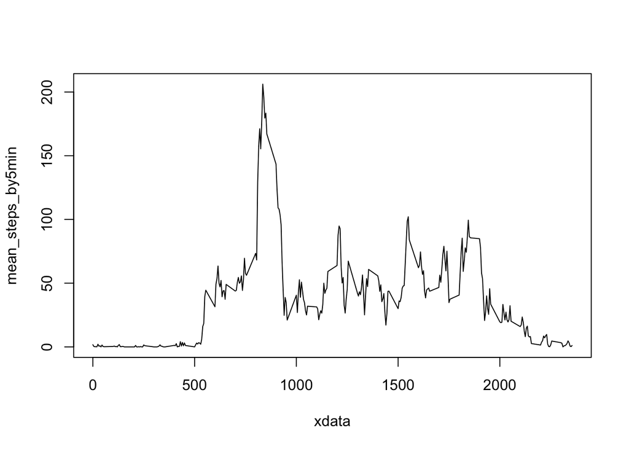

```r
mean_steps_by5min <- tapply(ads$steps, ads$interval, mean, na.rm = TRUE)
xdata <- unique(ads$interval)
plotdata <- data.frame(xdata,mean_steps_by5min)
plot(plotdata, type = "l")
```

```r
max_5min <- names(mean_steps_by5min[which.max(mean_steps_by5min)])
```

## Imputing missing values

```r
na_count <- sum(is.na(ads[,1]))
```

2. Devise a strategy for filling in all of the missing values in the dataset. The strategy does not need to be sophisticated. For example, you could use the mean/median for that day, or the mean for that 5-minute interval, etc.

```r
ads_nona <- data.frame()
interval_mean <- aggregate(steps ~ interval, data = ads, FUN = mean)
for (i in 1:nrow(ads)) {
    rowdata <- ads[i, ]
    if (is.na(rowdata$steps)) {
        steps <- subset(interval_mean, interval == rowdata$interval)$steps
    } else {
        steps <- rowdata$steps
    }
    ads_nona[i,1] <- steps
}
```

3. Create a new dataset that is equal to the original dataset but with the missing data filled in.

```r
ads_nona[,2] <- ads[,2]
ads_nona[,3] <- ads[,3]
colnames(ads_nona) <- c("steps","date","interval")
ads_nona$date <- as.Date(ads_nona$date)
```

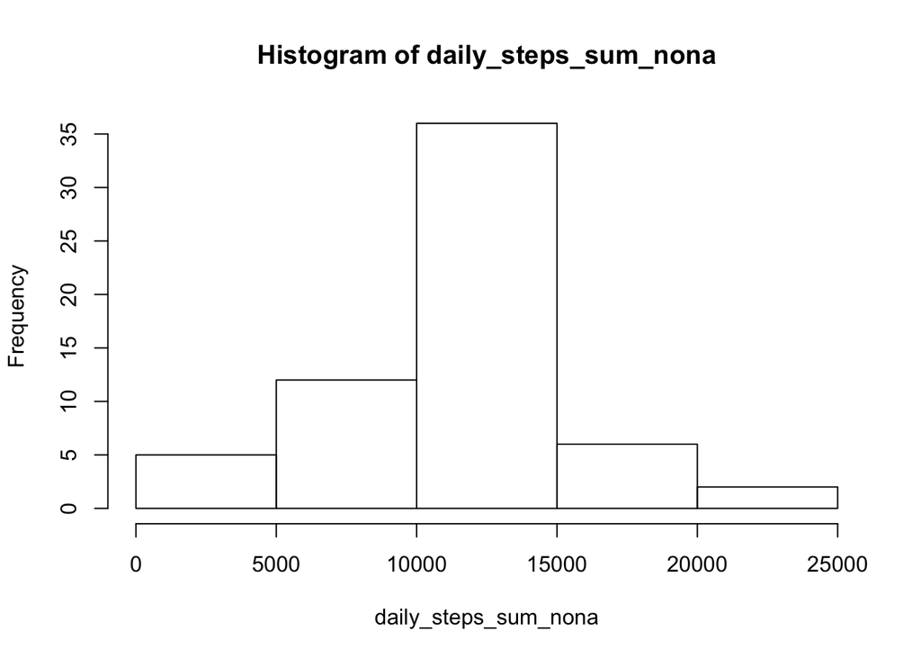

```r
daily_steps_sum_nona <- tapply(ads_nona$steps, format(ads_nona$date, '%d-%m-%Y'), sum)
hist(daily_steps_sum_nona)
```

```r
daily_steps_nona_mean <- mean(daily_steps_sum_nona, na.rm = TRUE)
daily_steps_nona_median <- median(daily_steps_sum_nona, na.rm = TRUE)
```

## Are there differences in activity patterns between weekdays and weekends?

1. Create a new factor variable in the dataset with two levels – “weekday” and “weekend” indicating whether a given date is a weekday or weekend day.

```r
day <- weekdays(ads_nona$date)
dayofweek <- vector()
for (i in 1:nrow(ads_nona)) {
    if (day[i] == "Saturday") {
        dayofweek[i] <- "weekend"
    } else if (day[i] == "Sunday") {
        dayofweek[i] <- "weekend"
    } else {
        dayofweek[i] <- "weekday"
    }
}
ads_nona$dayofweek <- dayofweek
ads_nona$dayofweek <- factor(ads_nona$dayofweek)
```

2. Make a panel plot containing a time series plot (i.e. type = “l”) of the 5-minute interval (x-axis) and the average number of steps taken, averaged across all weekday days or weekend days (y-axis). See the README file in the GitHub repository to see an example of what this plot should look like using simulated data.

[figure not shown]

```r
library(lattice)
mean_steps_by5min_nona <- aggregate(steps ~ interval + dayofweek, data = ads_nona, mean)
names(mean_steps_by5min_nona) <- c("interval", "daylevel", "steps")
xyplot(steps ~ interval | dayofweek, layout = c(1, 2), type = "l", xlab = "Interval", ylab = "Number of steps", mean_steps_by5min_nona)
```